# Top Hitters: OPS vs wRC+

What a year for baseball, folks. After a dreadful, but necessary, 60-game season in 2020, we got our long awaited full 162-game season and nothing brings more join to an analytics person than a nice sample size.

[figure not shown]

We can now dig deeper on what we saw or did not see last year. We can go through the data, or splits of it which is my case, and check out what happened. Who was good? When were they good? Against whom? That is what we are going to try to figure out here and, hopefully, give you some ideas to build your fantasy roster, stream some guys or just have fun reading it. So let’s dive in!

Splitting last year’s data for hitters against left-handed pitchers (LHP) and right-handed pitchers (RHP), let’s see if we can find out who were the best hitters against each kind of pitcher based on On-base Plus Sluggins (OPS) and Weighted Runs Created Plus (wRC+).

## Against LHP (OPS > 1 and wRC+ > 150)

I know. Those are insane numbers, but some guys were there and a feel went above and beyond to be elite against LHP - and I mean ELITE. Only 17 guys were able to perform like that. Can you guess some of the top 5 names?

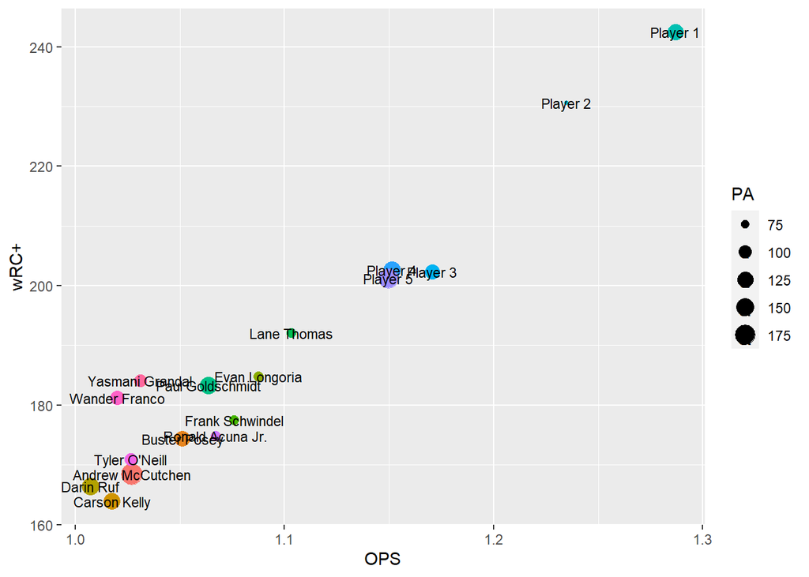

### Mike Zunino (OPS: 1.287 wRC+: 242.47 Pa: 129)

No. That is not a typo. Zunino got a 242.47 wRC+ against LHP. That means he produced 142% more runs than an average MLB player when hitting lefties. To put things in perspective, Vladdy, who was going for a triple crown last year, got a 155.8 wRC+ in 173 Pa. That is 55.8% more runs than league average, which is good, but it is not even close to Zunino’s numbers. He was a *beast* against lefties slashing 0.342/0.418/0.868 with 16 HR. If he is free on your league, I would totally stash him, or even start him. He can be a total asset when the Rays face left-handed pitching this season. Oh, and let’s not forget he led the league last season with 24.3 barrel%.

### Luis Robert (OPS: 1.235 wRC+: 230.63 Pa: 68)

I know, I don’t like the 68 plate appearances either, but if it is good enough for Fangraphs to include in this data split, it is good enough for me. Robert slashed 0.396/0.441/0.793 with 6 HR against lefties last year. The small sample takes a little of the confidence on those numbers for sure, but we also have to remember that this is only his second season in the majors, and it would have been the first full season if not for the injuries he faced. If he can have a full season maintaining his health, what does not seem to be a problem, we can expect regression, but still awesome numbers from him against LHP this year.

### Ketel Marte (OPS: 1.171 wRC+: 202.34 Pa: 115)

It’s not 2019 numbers. A small sample looks good on Marte, right? Playing only 90 games due to injury, Marte was incredible against LHP. The switch hitter slashed .387/.435/.736, which is not even close to what he did against RHP. Next to the two guys above he may not seem that impressive, but believe me, being able to produce 102% more runs than an average league average player is something. A guy with these numbers at one side of the plate and second-base eligibility can really help some folks out there, and we have already seem what he can do in a full season.

### Teoscar Hernández (OPS: 1.151 wRC+: 202.66 Pa: 140)

Almost 77% of Hernández’s plate appearances were against RHP (455), but when he faces lefties it is hard to stop this man. He slashed .372/.407/.744 with 12 HR against left-handed pitching and the best of all: he is getting better. He had an incredible 2020 season smashing 16 HR in 50 games against both sides and in 2021 he was able to keep his elite numbers very close to the previous year while improving his K% from 12 to 26 percentile across the league. Safe to say, Hernández has an elite bat and if he can get more Pa against left-handed pitchers, his value can go even higher.

### Trea Turner (OPS: 1.149 wRC+: 201.18 Pa: 167)

This is a guy who needs no introduction I believe. He slashed .392/.437/.712 against southpaws last year with 11 HR. Turner is an incredible asset for fantasy with his combination of power-speed that is hard to match, but apparently, there is a catch. He only runs with righties on the mound. Out of his 32 stolen bases last year, he only attempted to steal 6 times against lefties with 2 caught stealings. This obviously don’t affect his value as a hitter, but it is a nice fun fact because there is not much to say about Turner, except that he is good hitter and even a better one against opposite-hand pitchers.

## Against RHP (OPS > 0.950 and wRC+ > 150)

Now from the other side of the throwing arm, things get a little more interesting. Most of them are expected, a bit more plate appearances, but the same amount of fun. Check it out!

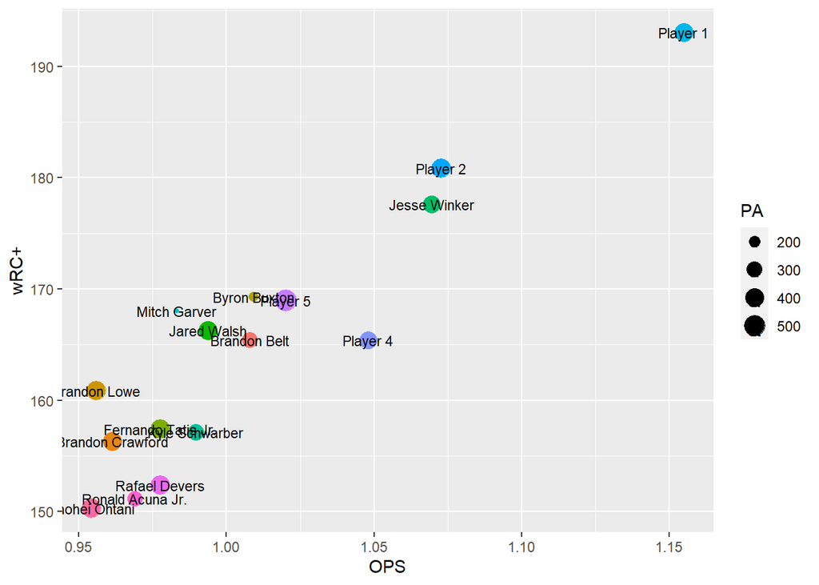